```python
# install and import necessary packages.
import sys

!{sys.executable} -m pip install pandas
!{sys.executable} -m pip install matplotlib
!{sys.executable} -m pip install statsmodels
!{sys.executable} -m pip install numpy
!{sys.executable} -m pip install requests
```

```python
import pandas as pd
import matplotlib.pyplot as plt
import re
import requests
import numpy as np
from datetime import datetime
from statsmodels.tsa.seasonal import seasonal_decompose
```

# Data Loading, Data Cleaning and Data Quality Issues

```python
file_location = "/Users/ipokharel/dev/cybersyn/iowa_liquor_sales_2018_2021.csv"

#Please change the file path to where you have the file saved before running the file.
df = pd.read_csv(file_location, sep = ",")
```

```python
# describe the data
print(f"There are {df.shape[0]} and {df.shape[1]} columns in the initital dataset." )
```

```
There are 10087862 and 24 columns in the initital dataset.
```

```python
df.info()
```

```
<class 'pandas.core.frame.DataFrame'>
RangeIndex: 10087862 entries, 0 to 10087861
Data columns (total 24 columns):
 #   Column                 Dtype
---  ------                 -----
 0   Invoice/Item Number    object
 1   Date                   object
 2   Store Number           int64
 3   Store Name             object
 4   Address                object
 5   City                   object
 6   Zip Code               float64
 7   Store Location         object
 8   County Number          float64
 9   County                 object
```

[output cut: 16 more lines]

```python
#Checking if there are any duplicates in the dataset.
df["Invoice/Item Number"].is_unique
```

```
True
```

```python
#checking null values in the dataframe.
print(f"Calculating the percentage of missing (null) values for each column in a initial dataframe" )
print((df.isnull().sum() / len(df)) * 100)
```

```
Calculating the percentage of missing (null) values for each column in a initial dataframe
Invoice/Item Number     0.000
Date                    0.000
Store Number            0.000
Store Name              0.000
Address                 0.073
City                    0.073
Zip Code                0.073
Store Location          9.951
County Number           0.073
County                  0.073
Category                0.057
Category Name           0.057
Vendor Number           0.000
Vendor Name             0.000
Item Number             0.000
Item Description        0.000
Pack                    0.000
Bottle Volume (ml)      0.000
State Bottle Cost       0.000
State Bottle Retail     0.000
Bottles Sold            0.000
Sale (Dollars)          0.000
Volume Sold (Liters)    0.000
Volume Sold (Gallons)   0.000
dtype: float64
```

It appears that the 'Store Location' column is missing approximately 10% of the total values in the dataset. Among the other columns with missing values, none of them seem to have more than 0.7% of missing values in the total rows of the dataframe. Instead of removing rows with null values immediately, I will first remove the columns from the dataframe that are not necessary for answering the questions posed in the case study. Removing rows with null values at this stage might result in the removal of rows that are not necessarily required to be eliminated.

To prepare the dataset for analysis, I'll remove the following columns. **"Address", "City", "Zip Code", "Store Location", "County Number", "County", "Category", "Vendor Number", "Item Number"**

```python
#drop the columns
columns_to_drop = ["Invoice/Item Number","Address", "City", "Zip Code", "Store Location", "County Number", "County", "Category", "Vendor Number", "Item Number"]
try:
    df.drop(columns=columns_to_drop, inplace=True)
except KeyError as e:
    print(e)
    pass  # Suppress any KeyError (index not found) and continue
```

```python
missing_rows = ((df.isnull().sum() / len(df)) * 100)
missing_rows
```

```
Date                    0.000
Store Number            0.000
Store Name              0.000
Category Name           0.057
Vendor Name             0.000
Item Description        0.000
Pack                    0.000
Bottle Volume (ml)      0.000
State Bottle Cost       0.000
State Bottle Retail     0.000
Bottles Sold            0.000
Sale (Dollars)          0.000
Volume Sold (Liters)    0.000
Volume Sold (Gallons)   0.000
dtype: float64
```

We only have the **'Category Name'** column with some missing values. I won't drop any rows of data until I reach the point where I need to perform analysis using the 'Category Name' column because dropping rows at this point might cause us to lose some information from other columns where data might not be missing.

#### Changing column types to appropriate values.

```python
duplicates = df[df.duplicated()]
duplicates
```

|  | Date | Store Number | Store Name | Category Name | Vendor Name | Item Description | Pack | Bottle Volume (ml) | State Bottle Cost | State Bottle Retail | Bottles Sold | Sale (Dollars) | Volume Sold (Liters) | Volume Sold (Gallons) |
| --- | --- | --- | --- | --- | --- | --- | --- | --- | --- | --- | --- | --- | --- | --- |
| 4109 | 03/06/2019 | 3773 | BENZ DISTRIBUTING | CANADIAN WHISKIES | CONSTELLATION BRANDS INC | BLACK VELVET TOASTED CARAMEL | 12 | 750 | 6.750 | 10.130 | 12 | 121.560 | 9.000 | 2.370 |
| 4768 | 03/12/2019 | 5653 | MIKE'S MARKET AND DELI | TEMPORARY & SPECIALTY PACKAGES | DIAGEO AMERICAS | CROWN ROYAL PEACH | 12 | 750 | 15.590 | 23.390 | 12 | 280.680 | 9.000 | 2.370 |
| 5479 | 03/15/2019 | 5469 | CHROME TRUCK STOP | CANADIAN WHISKIES | DIAGEO AMERICAS | CROWN ROYAL REGAL APPLE | 12 | 750 | 15.590 | 23.390 | 12 | 280.680 | 9.000 | 2.370 |
| 5918 | 03/07/2019 | 4001 | WAL-MART 1787 / CARROLL | CANADIAN WHISKIES | DIAGEO AMERICAS | CROWN ROYAL VANILLA | 12 | 750 | 15.590 | 23.390 | 12 | 280.680 | 9.000 | 2.370 |
| 6508 | 03/04/2019 | 2191 | KEOKUK SPIRITS | CANADIAN WHISKIES | DIAGEO AMERICAS | CROWN ROYAL REGAL APPLE | 12 | 1000 | 18.890 | 28.340 | 24 | 680.160 | 24.000 | 6.340 |
| ... | ... | ... | ... | ... | ... | ... | ... | ... | ... | ... | ... | ... | ... | ... |
| 10086878 | 07/31/2018 | 4161 | FAREWAY STORES #950 / IOWA CITY | AMERICAN VODKAS | LAIRD & COMPANY | FIVE O'CLOCK VODKA | 12 | 750 | 3.370 | 5.060 | 12 | 60.720 | 9.000 | 2.380 |
| 10087043 | 07/31/2018 | 4161 | FAREWAY STORES #950 / IOWA CITY | AMERICAN VODKAS | DIAGEO AMERICAS | SMIRNOFF PET 80PRF | 6 | 1750 | 14.750 | 22.130 | 6 | 132.780 | 10.500 | 2.770 |
| 10087109 | 07/31/2018 | 4161 | FAREWAY STORES #950 / IOWA CITY | STRAIGHT BOURBON WHISKIES | CEDAR RIDGE VINEYARDS LL | CEDAR RIDGE BOURBON | 6 | 750 | 18.100 | 27.150 | 6 | 162.900 | 4.500 | 1.190 |
| 10087176 | 07/30/2018 | 4312 | I-80 LIQUOR / COUNCIL BLUFFS | STRAIGHT BOURBON WHISKIES | SKYY SPIRITS INC | WILD TURKEY 101 | 12 | 1000 | 16.660 | 24.990 | 12 | 299.880 | 12.000 | 3.170 |
| 10087856 | 03/20/2019 | 3773 | BENZ DISTRIBUTING | STRAIGHT RYE WHISKIES | CEDAR RIDGE VINEYARDS LL | CEDAR RIDGE MALTED RYE | 6 | 750 | 19.670 | 29.510 | 6 | 177.060 | 4.500 | 1.180 |

21611 rows × 14 columns

```python
df.dtypes
```

```
Date                      object
Store Number               int64
Store Name                object
Category Name             object
Vendor Name               object
Item Description          object
Pack                       int64
Bottle Volume (ml)         int64
State Bottle Cost        float64
State Bottle Retail      float64
Bottles Sold               int64
Sale (Dollars)           float64
Volume Sold (Liters)     float64
Volume Sold (Gallons)    float64
dtype: object
```

```python
#changing Date to datetime object.
df["Date"] = pd.to_datetime(df["Date"], format='%m/%d/%Y') # change date to datetime format, dont need HH-MM-SS data
#store number should be change to object type because we can't perform any arithmetic operations on them,
df["Store Number"] = df["Store Number"].astype("str")
```

Data Validation. In the data documentation, the following descriptions are present, so i'm going to test the accuracy by creating custom data check formulas.

- Total cost of liquor order (number of bottles multiplied by the state bottle retail)
- Total volume of liquor ordered in liters. (i.e. (Bottle Volume (ml) x Bottles Sold)/1,000)
- Total volume of liquor ordered in gallons. (i.e. (Bottle Volume (ml) x Bottles Sold)/3785.411784)

#### Checking accuracy of total cost of liquor order **Sales (Dollar)** column

Formula used **Sales (Dollar)** = **Bottles Sold** * **State Bottle Retail**

```python
df["Sale (Dollars) Expected"] = df["Bottles Sold"] * df["State Bottle Retail"]
mismatched_rows = df[round(df["Sale (Dollars)"],0) != round(df["Sale (Dollars) Expected"],0)]
percent_mismatch_sale_dollars = (len(mismatched_rows)/len(df))*100
#print(mismatched_rows.shape)
print(f"{round(percent_mismatch_sale_dollars,2)}% of the total rows do not match the formula Sale (Dollars) = Bottles Sold * State Bottle Retail")
```

```
3.65% of the total rows do not match the formula Sale (Dollars) = Bottles Sold * State Bottle Retail
```

It is possible that some discounts were applied, causing a slight discrepancy in the Total Sale (Dollars).

To address this, we will remove all the rows where the data is off by 20% or more, assuming that a maximum discount of 20% could be the cause of the Total Sale (Dollars) not matching the formula **Sales (Dollar)** = **Bottles Sold** * **State Bottle Retail**

```python
df["Sale (Dollars) Expected discount"] = df["Sale (Dollars) Expected"] - .20 * df["Sale (Dollars) Expected"]
mismatched_rows_discount = df[ (round(df["Sale (Dollars)"],0) != round(df["Sale (Dollars) Expected"],0)) &
                        (round(df["Sale (Dollars)"],0) <= round(df["Sale (Dollars) Expected discount"],0) )]
percent_mismatch_sale_dollars_discount = (len(mismatched_rows_discount)/len(df))*100
print(mismatched_rows_discount.shape)
print(f"{round(percent_mismatch_sale_dollars_discount,2)}% of the total rows do not match the formula Sale (Dollars) = Bottles Sold * State Bottle Retail even after 20% discount is applied to expected Sales amount")
```

```
(16566, 16)
0.16% of the total rows do not match the formula Sale (Dollars) = Bottles Sold * State Bottle Retail even after 20% discount is applied to expected Sales amount
```

I will remove the rows where **'Sale (Dollars)'** does not match the calculated expected sales amount, even after considering a 20% discount applied to the expected sales amount.

```python
#remove all rows where expected sales amount does not match the sales total amount after 20% max discount was applied.
try:
    df.drop(mismatched_rows_discount.index, inplace=True)
    cols_to_drop = ["Sale (Dollars) Expected","Sale (Dollars) Expected discount"]
    df.drop(cols_to_drop, axis = 1, inplace = True) #drop temporary columns
except KeyError:
    pass  # Suppress any KeyError (index not found) and continue
print(df.columns)
```

```
Index(['Date', 'Store Number', 'Store Name', 'Category Name', 'Vendor Name',
       'Item Description', 'Pack', 'Bottle Volume (ml)', 'State Bottle Cost',
       'State Bottle Retail', 'Bottles Sold', 'Sale (Dollars)',
       'Volume Sold (Liters)', 'Volume Sold (Gallons)'],
      dtype='object')
```

Formula used **Volume Sold (Liters)** = **(Bottle Volume (ml)** x **Bottles Sold**)/1,000)

```python
df["Volume Sold (Liters) Expected"] = (df["Bottle Volume (ml)"] * df["Bottles Sold"])/1000
#rounding it to 0 because i dont want rounding error mismatch to attribute to error data
mismatched_rows_volume = df[round(df["Volume Sold (Liters) Expected"],0) != round(df["Volume Sold (Liters)"],0)]
mismatched_rows_volume_percent = (len(mismatched_rows_volume)/len(df))*100
print(mismatched_rows_volume.shape)
mismatched_rows_volume[["Volume Sold (Liters) Expected","Volume Sold (Liters)"]]
print(f"{round(mismatched_rows_volume_percent,4)}% of the total rows do not match the formula Volume Sold (Liters) = (Bottle Volume (ml)] x ]Bottles Sold])/1,000)")
```

```
(0, 15)
0.0% of the total rows do not match the formula Volume Sold (Liters) = (Bottle Volume (ml)] x ]Bottles Sold])/1,000)
```

```python
#remove all rows where expected sales amount does not match the sales total amount after 20% max discount was applied.
try:
    df.drop(mismatched_rows_volume.index, inplace=True)
    df.drop(["Volume Sold (Liters) Expected"], axis = 1, inplace = True) #drop temporary columns
except KeyError:
    pass  # Suppress any KeyError (index not found) and continue
print(df.columns)
```

```
Index(['Date', 'Store Number', 'Store Name', 'Category Name', 'Vendor Name',
       'Item Description', 'Pack', 'Bottle Volume (ml)', 'State Bottle Cost',
       'State Bottle Retail', 'Bottles Sold', 'Sale (Dollars)',
       'Volume Sold (Liters)', 'Volume Sold (Gallons)'],
      dtype='object')
```

We can repeat the same process to check accuracy of **Volume Sold (Gallons)** column but we won't be using that columns. Let's just do it because we've come this far :) Formula used: **Volume Sold (Gallons)** = **Volume Sold (Liters)**/**3.785411784**)

```python
df["Volume Sold (Gallons) Expected"] = round(df["Volume Sold (Liters)"]/3.785411784,2)
#rounding it to 0 because i don't want to include rounding errors as wrong data
mismatched_rows_volume_gallon = df[round(df["Volume Sold (Gallons) Expected"], 0) != round(df["Volume Sold (Gallons)"],0)]
mismatched_rows_volume_gallon[["Volume Sold (Gallons) Expected","Volume Sold (Gallons)"]]
```

|  | Volume Sold (Gallons) Expected | Volume Sold (Gallons) |
| --- | --- | --- |
| 236220 | 2.510 | 2.500 |
| 1072209 | 1747.500 | 1747.490 |
| 1304837 | 1747.500 | 1747.490 |
| 3928380 | 1747.500 | 1747.490 |
| 6898189 | 1747.500 | 1747.490 |

Looks like the only error is in the rounding mismatch. The data is fine.

```python
try:
    df.drop(["Volume Sold (Gallons) Expected"])
except Exception as e:
    print(e)
    pass
```

```
"['Volume Sold (Gallons) Expected'] not found in axis"
```

#### Checking accuracy of **Pack** Field.

```python
print(sorted(df["Pack"].unique().tolist()))
```

```
[1, 2, 3, 4, 5, 6, 8, 9, 10, 12, 15, 16, 18, 20, 24, 28, 30, 32, 44, 48, 60, 120]
```

Since **Pack** is the number of bottles in a case for the liquor ordered. None of these numbers seem to be off. There are 120 bottles in a case for some of the liquors ( I am imagining the those 1 dollar shots at the counter would account for these).

#### Checking accuracy of **numeric** columns

```python
numeric_columns = ["Bottle Volume (ml)",
                   "State Bottle Cost",
                   "State Bottle Retail",
                   "Bottles Sold",
                   "Sale (Dollars)",
                   "Volume Sold (Liters)",
                   "Volume Sold (Gallons)"]

#describe data in human readable format.
pd.set_option('display.float_format', lambda x: '%.3f' % x)
df[numeric_columns].describe()
```

|  | Bottle Volume (ml) | State Bottle Cost | State Bottle Retail | Bottles Sold | Sale (Dollars) | Volume Sold (Liters) | Volume Sold (Gallons) |
| --- | --- | --- | --- | --- | --- | --- | --- |
| count | 10071296.000 | 10071296.000 | 10071296.000 | 10071296.000 | 10071296.000 | 10071296.000 | 10071296.000 |
| mean | 861.238 | 10.698 | 16.048 | 11.353 | 151.162 | 9.336 | 2.462 |
| std | 523.192 | 9.791 | 14.686 | 32.700 | 533.155 | 38.737 | 10.233 |
| min | 20.000 | 0.330 | 0.500 | 0.000 | 1.300 | 0.020 | 0.000 |
| 25% | 750.000 | 5.650 | 8.480 | 3.000 | 36.880 | 1.500 | 0.400 |
| 50% | 750.000 | 8.660 | 12.990 | 6.000 | 78.660 | 4.800 | 1.260 |
| 75% | 1000.000 | 13.000 | 19.500 | 12.000 | 154.800 | 10.500 | 2.770 |
| max | 6000.000 | 2098.940 | 3148.410 | 13200.000 | 279557.280 | 13200.000 | 3487.070 |

Some of the max values shown in the table above seems a bit off. In the following sections, I am manually verifying whether the maximum values displayed in the dataset summary are reasonable.

```python
df[ df['Sale (Dollars)'] == max(df['Sale (Dollars)']) ]
```

|  | Date | Store Number | Store Name | Category Name | Vendor Name | Item Description | Pack | Bottle Volume (ml) | State Bottle Cost | State Bottle Retail | Bottles Sold | Sale (Dollars) | Volume Sold (Liters) | Volume Sold (Gallons) | Volume Sold (Gallons) Expected |
| --- | --- | --- | --- | --- | --- | --- | --- | --- | --- | --- | --- | --- | --- | --- | --- |
| 7437812 | 2018-10-02 | 2663 | HY-VEE FOOD STORE / URBANDALE | CANADIAN WHISKIES | DIAGEO AMERICAS | CROWN ROYAL | 12 | 750 | 15.590 | 23.390 | 11952 | 279557.280 | 8964.000 | 2368.030 | 2368.040 |

```python
df[ df['State Bottle Cost'] == max(df['State Bottle Cost']) ]
```

|  | Date | Store Number | Store Name | Category Name | Vendor Name | Item Description | Pack | Bottle Volume (ml) | State Bottle Cost | State Bottle Retail | Bottles Sold | Sale (Dollars) | Volume Sold (Liters) | Volume Sold (Gallons) | Volume Sold (Gallons) Expected |
| --- | --- | --- | --- | --- | --- | --- | --- | --- | --- | --- | --- | --- | --- | --- | --- |
| 5433195 | 2021-04-16 | 5257 | MAD AVE QUIK SHOP | IMPORTED BRANDIES | REMY COINTREAU USA INC | REMY MARTIN LOUIS XIII | 1 | 750 | 2098.940 | 3148.410 | 2 | 6296.820 | 1.500 | 0.390 | 0.400 |
| 6057928 | 2021-05-19 | 2647 | HY-VEE #7 / CEDAR RAPIDS | IMPORTED BRANDIES | REMY COINTREAU USA INC | REMY MARTIN LOUIS XIII | 1 | 750 | 2098.940 | 3148.410 | 1 | 3148.410 | 0.750 | 0.190 | 0.200 |
| 6062262 | 2021-05-20 | 2538 | HY-VEE FOOD STORE #3 / WATERLOO | IMPORTED BRANDIES | REMY COINTREAU USA INC | REMY MARTIN LOUIS XIII | 1 | 750 | 2098.940 | 3148.410 | 1 | 3148.410 | 0.750 | 0.190 | 0.200 |
| 6128566 | 2021-05-28 | 4829 | CENTRAL CITY 2 | IMPORTED BRANDIES | REMY COINTREAU USA INC | REMY MARTIN LOUIS XIII | 1 | 750 | 2098.940 | 3148.410 | 1 | 3148.410 | 0.750 | 0.190 | 0.200 |

```python
df[ df['Bottles Sold'] == max(df['Bottles Sold']) ]
```

|  | Date | Store Number | Store Name | Category Name | Vendor Name | Item Description | Pack | Bottle Volume (ml) | State Bottle Cost | State Bottle Retail | Bottles Sold | Sale (Dollars) | Volume Sold (Liters) | Volume Sold (Gallons) | Volume Sold (Gallons) Expected |
| --- | --- | --- | --- | --- | --- | --- | --- | --- | --- | --- | --- | --- | --- | --- | --- |
| 4668903 | 2020-10-08 | 2633 | HY-VEE #3 / BDI / DES MOINES | AMERICAN VODKAS | FIFTH GENERATION INC | TITOS HANDMADE VODKA | 12 | 1000 | 12.670 | 19.010 | 13200 | 250932.000 | 13200.000 | 3487.070 | 3487.070 |
| 4906813 | 2021-07-05 | 2633 | HY-VEE #3 / BDI / DES MOINES | AMERICAN VODKAS | FIFTH GENERATION INC | TITOS HANDMADE VODKA | 12 | 1000 | 12.670 | 19.010 | 13200 | 250932.000 | 13200.000 | 3487.070 | 3487.070 |
| 5445851 | 2021-04-19 | 2633 | HY-VEE #3 / BDI / DES MOINES | AMERICAN VODKAS | FIFTH GENERATION INC | TITOS HANDMADE VODKA | 12 | 1000 | 12.670 | 19.010 | 13200 | 250932.000 | 13200.000 | 3487.070 | 3487.070 |

Based on the individual row-level data, it appears that there were some significant purchases that led to these numeric fields having such high values. In the case of a high retail price, it looks like the items purchased were Imported Brandies. The same seems to be the case for the high State Bottle Cost variable.

#### Checking Date Variable

```python
df['Date'].describe()
```

```
count                         10071296
mean     2020-01-15 08:29:42.256106240
min                2017-12-15 00:00:00
25%                2019-01-08 00:00:00
50%                2020-01-31 00:00:00
75%                2021-01-15 00:00:00
max                2021-12-31 00:00:00
Name: Date, dtype: object
```

We don't need 2017 data for this analysis so we're going to remove the 2017 data from the dataset.

```python
#remvoe all 2017 data from the dataset.
df = df[df['Date'].dt.year != 2017]
df['Date'].describe()
```

```
count                          9956532
mean     2020-01-24 01:01:39.424980736
min                2018-01-02 00:00:00
25%                2019-01-24 00:00:00
50%                2020-02-11 00:00:00
75%                2021-01-20 00:00:00
max                2021-12-31 00:00:00
Name: Date, dtype: object
```

### Question 1

What impact did Covid have on the overall liquor market in Iowa?

- a) What trends evolved over the next 3-18 months?
- b) Was there a notable shift in the types of products purchased in terms of pack size

##### 1a) What trends evolved over the next 3-18 months?

```python
#resampling data to monthly level for Volume Sold (Liters) and Sale (Dollars).
monthly_sales_dollar = df.resample(rule = "MS", on = "Date")['Sale (Dollars)'].sum().to_frame(name = "Monthly Sales (Mil. $)")/1000000
monthly_sales_dollar.head(5)
```

| Date | Monthly Sales (Mil. $) |
| --- | --- |
| 2018-01-01 | 22.601 |
| 2018-02-01 | 22.856 |
| 2018-03-01 | 24.869 |
| 2018-04-01 | 26.210 |
| 2018-05-01 | 30.172 |

```python
#extract non seasonal trend from the monthly time series of sales.
result = seasonal_decompose(monthly_sales_dollar, model='multiplicative')
```

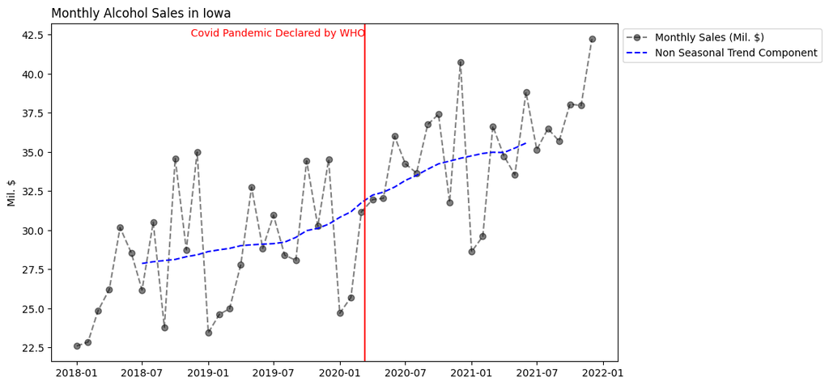

```python
#covid pandemic was announded as a pandemic on March, 11, 2020 by WHO
covid_pandemic_start_date = datetime(2020,3,11)
mean_before_pandemic = monthly_sales_dollar["Monthly Sales (Mil. $)"].loc[:covid_pandemic_start_date].mean()
mean_after_pandemic = monthly_sales_dollar["Monthly Sales (Mil. $)"].loc[covid_pandemic_start_date:].mean()


#plotting a graph to see alcohol sales in iowa from 2018 to 2021.
plt.figure(figsize = (10,6))
plt.plot(monthly_sales_dollar.index,
         monthly_sales_dollar["Monthly Sales (Mil. $)"],
         color = 'k',
         linestyle = 'dashed',
         label='Monthly Sales (Mil. $)',
         marker = 'o',
         alpha = 0.5
        )
plt.plot(
         result.trend,
         color = 'b',
         linestyle = 'dashed',
         label='Non Seasonal Trend Component'
        )
plt.axvline(x=covid_pandemic_start_date, color = "r" ) #, linestyle = "--"
plt.text(covid_pandemic_start_date,
         np.max(monthly_sales_dollar),
         'Covid Pandemic Declared by WHO',
         color='r',
         verticalalignment='bottom',
         horizontalalignment='right',
         rotation=0)
plt.title("Monthly Alcohol Sales in Iowa", loc = "left")
plt.ylabel("Mil. $")
#plt.axhline(y=mean_before_pandemic, color='b', linestyle='--', label='Mean Sales Mil.$ Before Pandemic', xmax=0.55)
#plt.axhline(y=mean_after_pandemic, color='g', linestyle='--', label='Mean Sales Mil.$ After Pandemic', xmin=0.55)
plt.legend(bbox_to_anchor=(1, 1))
plt.show()
#print(f"Mean Alcohol Spending in Iowa before pandemic was {round(mean_before_pandemic,2)} million dollars per month.")
#print(f"Mean Alcohol Spending in Iowa after pandemic was {round(mean_after_pandemic,2)}  million dollars per month.")
```

The plot illustrates the analysis of monthly alcohol sales data in Iowa from 2018 to 2021. Key observations are as follows:

- There is evident seasonality in the data, with regular upward and downward fluctuations.
- Before the COVID-19 pandemic, alcohol sales showed a rising trend.
- The start of the pandemic marked a significant shift in the trend, with increased sales.
- In the 3 to 18 months post-pandemic onset, the upward trend persisted.

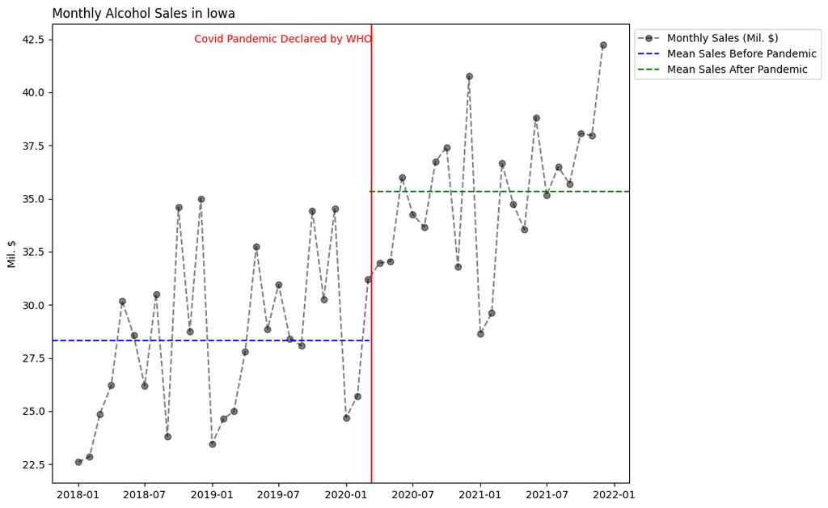

```
Mean Alcohol Spending in Iowa before pandemic was 28.33 million dollars per month.
Mean Alcohol Spending in Iowa after pandemic was 35.34  million dollars per month.
```

```python
#plotting a graph to see alcohol sales in iowa from 2018 to 2021.
plt.figure(figsize = (10,8))
plt.plot(monthly_sales_dollar.index,
         monthly_sales_dollar["Monthly Sales (Mil. $)"],
         color = 'k',
         linestyle = 'dashed',
         label='Monthly Sales (Mil. $)',
         marker = 'o',
         alpha = 0.5
        )
plt.axvline(x=covid_pandemic_start_date, color = "r" ) #, linestyle = "--"
plt.text(covid_pandemic_start_date,
         np.max(monthly_sales_dollar),
         'Covid Pandemic Declared by WHO',
         color='r',
         verticalalignment='bottom',
         horizontalalignment='right',
         rotation=0)
plt.title("Monthly Alcohol Sales in Iowa", loc = "left")
plt.ylabel("Mil. $")
plt.axhline(y=mean_before_pandemic, color='b', linestyle='--', label='Mean Sales Before Pandemic', xmax=0.55)
plt.axhline(y=mean_after_pandemic, color='g', linestyle='--', label='Mean Sales After Pandemic', xmin=0.55)
plt.legend(bbox_to_anchor=(1, 1))
plt.show()
print(f"Mean Alcohol Spending in Iowa before pandemic was {round(mean_before_pandemic,2)} million dollars per month.")
print(f"Mean Alcohol Spending in Iowa after pandemic was {round(mean_after_pandemic,2)}  million dollars per month.")
```

In the figure above, it's evident that the average alcohol sales exhibited a notable difference before and after the onset of the pandemic.

##### 1b) Was there a notable shift in the types of products purchased in terms of pack size

```python
# Pack represents the number of bottles in a case for the liquor ordered
pack_counts = df["Pack"].value_counts().sort_values(ascending=False)
print(pack_counts)
```

```
Pack
12     5371939
6      2878544
24      935751
48      274949
10      254078
1       102549
8        44906
5        35347
44       23786
4        14999
3        13937
9         1735
15        1389
60        1142
30         482
20         469
18         280
16         193
28          30
2           23
32           2
120          2
Name: count, dtype: int64
```

```python
#Lets get the top 10 pack size category based on the thier value counts in the dataset.
pack_list_sorted = pack_counts.index.tolist()[:6]
pack_list_sorted
```

```
[12, 6, 24, 48, 10, 1]
```

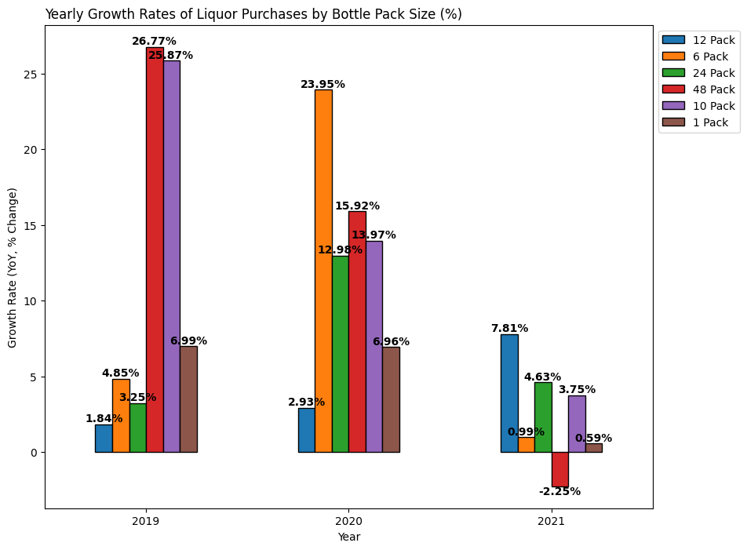

```python
def plot_pack_size_changes(data, pack_sizes):
    """
    Plot the yearly growth rates of liquor purchases by bottle pack size.

    Parameters:
    - data (DataFrame): The input dataset containing liquor purchase data.
    - pack_sizes (list of int): List of bottle pack sizes to analyze.

    Returns:
    - None: This function generates a bar plot of yearly growth rates.

    Example:
    plot_pack_size_changes(data=df, pack_sizes=[12, 6, 24, 48])
    """

    # Group the data by year and pack size, calculate the sum of bottles sold
    yearly_pack_size_stats = data.groupby([data.Date.dt.to_period('Y'), "Pack"]).agg({
        'Bottles Sold': 'sum'
    }).reset_index()

    # Pivot the data to create a table with years as rows and pack sizes as columns
    yearly_pack_size_stats = yearly_pack_size_stats.pivot(index="Date",
                                                          columns="Pack",
                                                          values="Bottles Sold"
                                                          ).reindex(columns=pack_sizes)
    # Calculate yearly growth rates as percentages
    yearly_pack_size_change = yearly_pack_size_stats.pct_change(axis=0, periods=1) * 100

    # Rename columns with pack size labels
    new_col_names = [f'{i} Pack' for i in pack_sizes]
    yearly_pack_size_change.columns = new_col_names

    # Remove data for the year 2018 if it exists
    try:
        yearly_pack_size_change = yearly_pack_size_change.drop("2018")
    except KeyError:
        pass

    # Create a bar plot
    ax = yearly_pack_size_change.plot(kind="bar",
                                     edgecolor='black',
                                     figsize=(10, 8))

    # Add labels to the bars with two decimal places and in bold
    for container in ax.containers:
        ax.bar_label(container, fmt='%.2f%%',
                     label_type='edge',
                     fontweight='bold')

    # Set plot title, x and y labels, and customize rotation of x-axis labels
    ax.set_title("Yearly Growth Rates of Liquor Purchases by Bottle Pack Size (%)",
                 loc="left")
    ax.set_xlabel("Year")
    ax.set_ylabel("Growth Rate (YoY, % Change)")
    ax.tick_params(axis='x', rotation=0)

    # Add a legend
    ax.legend(loc='upper left', bbox_to_anchor=(1, 1))

    # Show the plot
    plt.show()

# Example usage
plot_pack_size_changes(data=df, pack_sizes=[12, 6, 24, 48,10,1])
```

```python
import pandas as pd

def calculate_percentage_distribution(df, pack_sizes, target_year):
    """
    Calculate the percentage distribution of alcohol purchases based on bottle volume for specific pack sizes and year.

    Parameters:
    - df (DataFrame): The input dataset containing liquor purchase data.
    - pack_sizes (list of int): List of bottle pack sizes to analyze.
    - target_year (int): The year for which the percentage distribution is calculated.

    Returns:
    - percentage_distribution (Series): A Series with the percentage distribution of bottle volume for the specified pack sizes.

    Example:
    calculate_percentage_distribution(df, pack_sizes=[48], target_year=2019)
    """

    # Filter rows for the specific year
    filtered_df = df[pd.to_datetime(df["Date"]).dt.year == target_year]

    # Calculate the percentage distribution of "Bottle Volume (ml)" for specified pack sizes
    percentage_distribution = (filtered_df[filtered_df["Pack"].isin(pack_sizes)]["Bottle Volume (ml)"].value_counts() / len(filtered_df[filtered_df["Pack"].isin(pack_sizes)])) * 100

    # Print the percentage distribution with a clear message
    print(f"Percentage Distribution of Alcohol Purchases Based on Bottle Volume in Year {target_year} for Pack Sizes {pack_sizes}:")
    # Return the percentage distribution as a Series
    return percentage_distribution
print(calculate_percentage_distribution(df, pack_sizes=[48], target_year=2018))
print(calculate_percentage_distribution(df, pack_sizes=[48], target_year=2019))
```

```
Percentage Distribution of Alcohol Purchases Based on Bottle Volume in Year 2018 for Pack Sizes [48]:
Bottle Volume (ml)
200   73.400
100   26.600
Name: count, dtype: float64
Percentage Distribution of Alcohol Purchases Based on Bottle Volume in Year 2019 for Pack Sizes [48]:
Bottle Volume (ml)
200   67.475
100   32.525
Name: count, dtype: float64
```

```python
print(calculate_percentage_distribution(df, pack_sizes=[10], target_year=2018))
print(calculate_percentage_distribution(df, pack_sizes=[10], target_year=2019))
```

```
Percentage Distribution of Alcohol Purchases Based on Bottle Volume in Year 2018 for Pack Sizes [10]:
Bottle Volume (ml)
600   60.258
300   29.851
500    8.479
50     1.398
100    0.012
502    0.002
Name: count, dtype: float64
Percentage Distribution of Alcohol Purchases Based on Bottle Volume in Year 2019 for Pack Sizes [10]:
Bottle Volume (ml)
50    43.884
600   34.650
300   16.692
500    4.767
603    0.006
Name: count, dtype: float64
```

```python
print(calculate_percentage_distribution(df, pack_sizes=[6], target_year=2019))
print(calculate_percentage_distribution(df, pack_sizes=[6], target_year=2020))
```

```
Percentage Distribution of Alcohol Purchases Based on Bottle Volume in Year 2019 for Pack Sizes [6]:
Bottle Volume (ml)
1750   69.777
750    24.654
500     1.756
50      1.441
1000    1.409
600     0.272
800     0.231
1850    0.141
850     0.110
200     0.073
1800    0.060
100     0.020
2250    0.020
```

[output cut: 26 more lines]

```python
print(calculate_percentage_distribution(df, pack_sizes=[12], target_year=2019))
print(calculate_percentage_distribution(df, pack_sizes=[12], target_year=2020))
```

```
Percentage Distribution of Alcohol Purchases Based on Bottle Volume in Year 2019 for Pack Sizes [12]:
Bottle Volume (ml)
750    65.738
1000   21.146
375     4.936
500     4.099
50      3.631
200     0.378
20      0.025
25      0.018
300     0.012
800     0.009
250     0.007
Name: count, dtype: float64
Percentage Distribution of Alcohol Purchases Based on Bottle Volume in Year 2020 for Pack Sizes [12]:
Bottle Volume (ml)
750    68.321
1000   17.798
50      8.189
375     5.339
200     0.308
20      0.036
800     0.005
100     0.002
25      0.001
500     0.000
Name: count, dtype: float64
```

```python
df["Category Name"].unique()
```

```
array(['TENNESSEE WHISKIES', 'IMPORTED BRANDIES', 'SPICED RUM',
       'BLENDED WHISKIES', 'AMERICAN VODKAS', 'IMPORTED FLAVORED VODKA',
       'IMPORTED VODKAS', 'AMERICAN FLAVORED VODKA', 'IMPORTED DRY GINS',
       '100% AGAVE TEQUILA', 'GOLD RUM', 'STRAIGHT BOURBON WHISKIES',
       'COCKTAILS/RTD', 'CREAM LIQUEURS', 'CANADIAN WHISKIES',
       'FLAVORED RUM', 'SCOTCH WHISKIES', 'AMERICAN SCHNAPPS',
       'COFFEE LIQUEURS', 'WHITE RUM', 'WHISKEY LIQUEUR', 'MIXTO TEQUILA',
       'AMERICAN BRANDIES', 'AMERICAN DRY GINS', 'SPECIAL ORDER ITEMS',
       'IRISH WHISKIES', 'AMERICAN SLOE GINS', 'IMPORTED SCHNAPPS',
       'MEZCAL', 'TRIPLE SEC', 'STRAIGHT RYE WHISKIES',
       'TEMPORARY & SPECIALTY PACKAGES', 'IMPORTED CORDIALS & LIQUEURS',
       'NEUTRAL GRAIN SPIRITS', 'CORN WHISKIES',
       'AMERICAN CORDIALS & LIQUEURS', 'AGED DARK RUM',
       'IMPORTED DISTILLED SPIRITS SPECIALTY', 'SINGLE MALT SCOTCH',
       'BOTTLED IN BOND BOURBON', 'SINGLE BARREL BOURBON WHISKIES',
       'AMERICAN DISTILLED SPIRITS SPECIALTY', 'FLAVORED GIN', nan,
       'NEUTRAL GRAIN SPIRITS FLAVORED', 'IOWA DISTILLERY WHISKIES',
       'IOWA DISTILLERIES', 'IMPORTED GINS',
       'DISTILLED SPIRITS SPECIALTY', 'DELISTED / SPECIAL ORDER ITEMS',
       'IMPORTED WHISKIES', 'AMERICAN WHISKIES'], dtype=object)
```

### Question 2

Which are the fastest growing types of liquor (e.g., vodka, tequila, rum, etc.)? How has market share changed over time?  
a) Write a function that takes a list of liquor types as an input and visualizes the market share over time for each of those.  
b) What is driving the growth in tequila sales? Increases in average price or increases in volume sold?

I am categorizing all the unique alcohol categories the following way:

- **Whiskey:** TENNESSEE WHISKIES, BLENDED WHISKIES, STRAIGHT BOURBON WHISKIES, CANADIAN WHISKIES, IRISH WHISKIES, STRAIGHT RYE WHISKIES, BOTTLED IN BOND BOURBON, SINGLE BARREL BOURBON WHISKIES, AMERICAN WHISKIES, IOWA DISTILLERY WHISKIES
- **Rum:** SPICED RUM, GOLD RUM, FLAVORED RUM, WHITE RUM, AGED DARK RUM
- **Vodka:** AMERICAN VODKAS, IMPORTED FLAVORED VODKA, IMPORTED VODKAS, AMERICAN FLAVORED VODKA
- **Brandy:** IMPORTED BRANDIES, AMERICAN BRANDIES
- **Gin:** IMPORTED DRY GINS, AMERICAN DRY GINS, AMERICAN SLOE GINS, FLAVORED GIN
- **Tequila:** 100% AGAVE TEQUILA, MIXTO TEQUILA
- **Scotch:** SCOTCH WHISKIES, SINGLE MALT SCOTCH
- **Schnapps:** AMERICAN SCHNAPPS, IMPORTED SCHNAPPS
- **Liqueur:** CREAM LIQUEURS, COFFEE LIQUEURS, WHISKEY LIQUEUR, TRIPLE SEC
- **Specialty:** SPECIAL ORDER ITEMS, TEMPORARY & SPECIALTY PACKAGES, IMPORTED DISTILLED SPIRITS SPECIALTY, AMERICAN DISTILLED SPIRITS SPECIALTY
- **Grain Spirits:** NEUTRAL GRAIN SPIRITS, NEUTRAL GRAIN SPIRITS FLAVORED
- **Distilleries:** IOWA DISTILLERIES

```python
alcohol_categories_mapping = {
    'TENNESSEE WHISKIES': 'Whiskey',
    'IMPORTED BRANDIES': 'Brandy',
    'SPICED RUM': 'Rum',
    'BLENDED WHISKIES': 'Whiskey',
    'AMERICAN VODKAS': 'Vodka',
    'IMPORTED FLAVORED VODKA': 'Vodka',
    'IMPORTED VODKAS': 'Vodka',
    'AMERICAN FLAVORED VODKA': 'Vodka',
    'IMPORTED DRY GINS': 'Gin',
    '100% AGAVE TEQUILA': 'Tequila',
    'GOLD RUM': 'Rum',
    'STRAIGHT BOURBON WHISKIES': 'Whiskey',
    'COCKTAILS/RTD': 'Cocktail',
    'CREAM LIQUEURS': 'Liqueur',
    'CANADIAN WHISKIES': 'Whiskey',
    'FLAVORED RUM': 'Rum',
    'SCOTCH WHISKIES': 'Scotch',
    'AMERICAN SCHNAPPS': 'Schnapps',
    'COFFEE LIQUEURS': 'Liqueur',
    'WHITE RUM': 'Rum',
    'WHISKEY LIQUEUR': 'Liqueur',
    'MIXTO TEQUILA': 'Tequila',
    'AMERICAN BRANDIES': 'Brandy',
    'AMERICAN DRY GINS': 'Gin',
    'SPECIAL ORDER ITEMS': 'Specialty',
    'IRISH WHISKIES': 'Whiskey',
    'AMERICAN SLOE GINS': 'Gin',
    'IMPORTED SCHNAPPS': 'Schnapps',
    'MEZCAL': 'Tequila',
    'TRIPLE SEC': 'Liqueur',
    'STRAIGHT RYE WHISKIES': 'Whiskey',
    'TEMPORARY & SPECIALTY PACKAGES': 'Specialty',
    'IMPORTED CORDIALS & LIQUEURS': 'Liqueur',
    'NEUTRAL GRAIN SPIRITS': 'Grain Spirits',
    'CORN WHISKIES': 'Whiskey',
    'AMERICAN CORDIALS & LIQUEURS': 'Liqueur',
    'AGED DARK RUM': 'Rum',
    'IMPORTED DISTILLED SPIRITS SPECIALTY': 'Specialty',
    'SINGLE MALT SCOTCH': 'Scotch',
    'BOTTLED IN BOND BOURBON': 'Whiskey',
    'SINGLE BARREL BOURBON WHISKIES': 'Whiskey',
    'AMERICAN DISTILLED SPIRITS SPECIALTY': 'Specialty',
    'FLAVORED GIN': 'Gin',
    'NEUTRAL GRAIN SPIRITS FLAVORED': 'Grain Spirits',
    'IOWA DISTILLERY WHISKIES': 'Whiskey',
    'IOWA DISTILLERIES': 'Distilleries',
    'IMPORTED GINS': 'Gin',
    'DISTILLED SPIRITS SPECIALTY': 'Specialty',
    'DELISTED / SPECIAL ORDER ITEMS': 'Specialty',
    'IMPORTED WHISKIES': 'Whiskey',
    'AMERICAN WHISKIES': 'Whiskey',
     np.nan: 'Unspecified' # for nan values in category name

}
df["Broad Alcohol Categories"] = df["Category Name"].map(alcohol_categories_mapping)
df["Broad Alcohol Categories"].value_counts()
#df["Broad Alcohol Categories"].unique().tolist()
```

```
Broad Alcohol Categories
Whiskey          2565390
Vodka            2474871
Liqueur          1275277
Rum              1027012
Tequila           517879
Brandy            505256
Schnapps          473554
Gin               306305
Cocktail          295801
Scotch            235312
Specialty         214221
Grain Spirits      58969
Unspecified         5615
Distilleries        1070
Name: count, dtype: int64
```

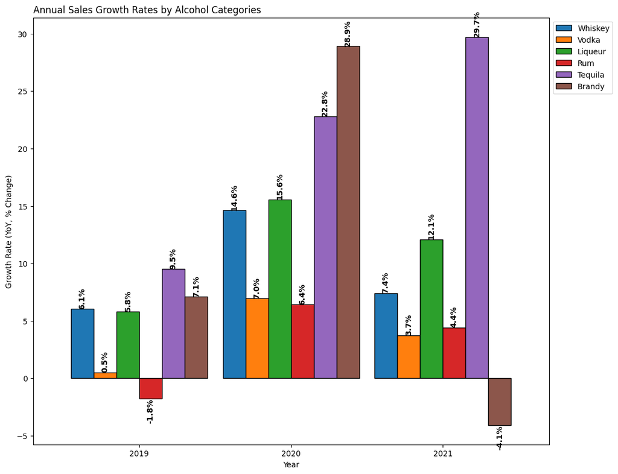

```python
def plot_growth_rates(data, alcohol_categories):
    """
    Plot the yearly growth rates of alcohol categories.

    Parameters:
    - data (DataFrame): The input dataset containing liquor purchase data.
    - alcohol_categories (list of alcohol categories): List of alcohol categories defined

    Returns:
    - None: This function generates a bar plot of yearly growth rates.

    Example:
    plot_pack_size_changes(data=df, alcohol_categories=['Whiskey', 'Brandy', 'Rum', 'Vodka', 'Gin'])
    """

    # Group the data by year and pack size, calculate the sum of bottles sold
    yearly_sales_categories = data.groupby([data.Date.dt.to_period('Y'), "Broad Alcohol Categories"]).agg({
        'Sale (Dollars)': 'sum'
    }).reset_index()

    # Pivot the data to create a table with years as rows and category sales as columns
    yearly_sales_categories_pivot = yearly_sales_categories.pivot(index="Date",
                                                          columns="Broad Alcohol Categories",
                                                          values='Sale (Dollars)'
                                                          ).reindex(columns=alcohol_categories)
    # Calculate yearly growth rates as percentages
    yearly_sales_size_change = yearly_sales_categories_pivot.pct_change(axis=0, periods=1) * 100

    # Rename columns with pack size labels
    new_col_names = alcohol_categories
    yearly_sales_size_change.columns = new_col_names

    # Remove data for the year 2018 if it exists
    try:
        yearly_sales_size_change = yearly_sales_size_change.drop("2018")
    except KeyError:
        pass

    # Create a bar plot
    ax = yearly_sales_size_change.plot(kind="bar",
                                     edgecolor='black',
                                     figsize=(12, 10),
                                      width=.9)

    # Add labels to the bars with two decimal places and in bold
    for container in ax.containers:
        ax.bar_label(container,
                     fmt='%.1f%%',
                     label_type='edge',
                     fontweight='bold',
                     rotation=90)

    # Set plot title, x and y labels, and customize rotation of x-axis labels
    ax.set_title("Annual Sales Growth Rates by Alcohol Categories",
                 loc="left")
    ax.set_xlabel("Year")
    ax.set_ylabel("Growth Rate (YoY, % Change)")
    ax.tick_params(axis='x', rotation=0)

    # Add a legend
    ax.legend(loc='upper left', bbox_to_anchor=(1, 1))

    # Show the plot
    plt.show()

# Example usage
plot_growth_rates(data=df, alcohol_categories=['Whiskey',
                                               'Vodka',
                                               'Liqueur',
                                               'Rum',
                                               'Tequila',
                                               'Brandy'
                                              #  ,
                                              #  'Schnapps',
                                              #  'Gin',
                                              #  'Scotch',
                                              # 'Specialty'
                                              ])
```

On the other hand, Brandy exhibited growth rates of 7.1% and 28.9% between 2018-2019 and 2019-2020. However, its sales experienced a decline of 4.1% between 2020 and 2021, signaling a shift in its market dynamics.

In terms of the fastest-growing types of liquor, Tequila emerges as a clear frontrunner.

##### a) Write a function that takes a list of liquor types as an input and visualizes the market share over time for each of those.

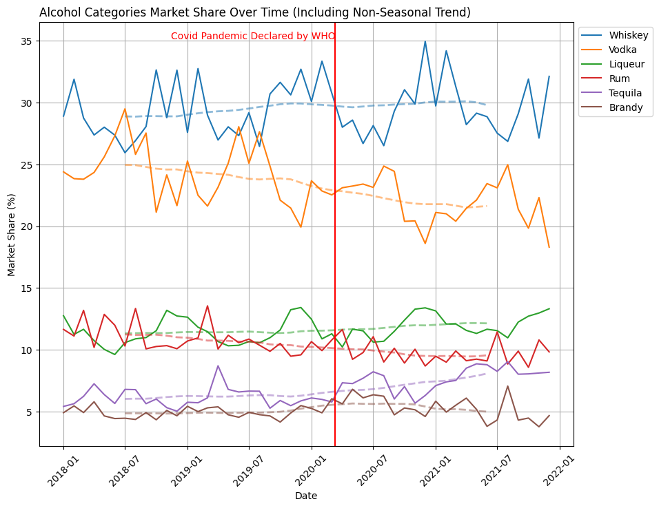

```python
def visualize_market_share(category_type, liquor_types, data=df):
    """
    Visualize the market share of selected liquor types over time.

    Parameters:
    - category_type (str): The category by which the data will be grouped (e.g., 'Alcohol Category', "Broad Alcohol Categories").
    - liquor_types (list): A list of liquor types to be visualized. Values provided in list should reflect what is chosen for category_type.
    - dataset (DataFrame, optional): The input dataset containing the original dataset for this case study. Default is 'data'.
    Returns:
    - None: This function generates a line plot to visualize the market share of the selected liquor types.

    Example:
    visualize_market_share(category_type='Broad Alcohol Categories', liquor_types=["Tequila", "Vodka", "Rum", "Whiskey"])
    or
    visualize_market_share(category_type='Category Name', liquor_types=["CANADIAN WHISKIES", "CREAM LIQUEURS", "AMERICAN FLAVORED VODKA", "AMERICAN BRANDIES"])

    """

    # Group the data by month and category, calculate market share
    # Calculate the percentage market share relative to the total for each month
    category_groupby = data.groupby([data.Date.dt.to_period('M'), category_type])[['Sale (Dollars)']].sum().rename(columns={'Sale (Dollars)': 'Market Share'})
    category_groupby_percent = (category_groupby / category_groupby.groupby(level=[0]).transform("sum") * 100).reset_index()

    # Convert the 'Date' column to datetime
    category_groupby_percent['Date'] = pd.to_datetime(category_groupby_percent['Date'].astype(str) + '-01', format='%Y-%m-%d')

    # Filter the data for selected liquor types
    filtered_data = category_groupby_percent[category_groupby_percent[category_type].isin(liquor_types)]

    # Pivot the data for plotting
    pivot_data = filtered_data.pivot(index='Date', columns=category_type, values='Market Share')

    plt.figure(figsize=(10, 8))
    linestyle = '--'  # Use dashed line style for trend lines
    for idx, liquor_type in enumerate(liquor_types):
        plt.plot(pivot_data.index, pivot_data[liquor_type], label=liquor_type)
        # Calculate and plot non seasonal trend line for each category_type with dashed line
        trend_line = seasonal_decompose(pivot_data[liquor_type], model='multiplicative').trend
        plt.plot(pivot_data.index, trend_line, linestyle=linestyle, color='C{}'.format(idx), linewidth=2, alpha=.5)

    plt.xlabel('Date')
    plt.ylabel('Market Share (%)')
    plt.title('Alcohol Categories Market Share Over Time (Including Non-Seasonal Trend)', loc="left")
    plt.xticks(rotation=45)
    plt.axvline(x=covid_pandemic_start_date, color = "r" ) #, linestyle = "--"
    plt.text(covid_pandemic_start_date,
         np.max(pivot_data["Whiskey"]),
         'Covid Pandemic Declared by WHO',
         color='r',
         verticalalignment='bottom',
         horizontalalignment='right',
         rotation=0)
    plt.legend(loc='best',bbox_to_anchor=(1, 1))
    plt.grid(True)

visualize_market_share(category_type='Broad Alcohol Categories',
                       liquor_types=['Whiskey',
                                     'Vodka',
                                    'Liqueur',
                                    'Rum',
                                    'Tequila',
                                    'Brandy'
                                    # 'Schnapps',
                                    # 'Gin',
                                    # 'Scotch',
                                    # 'Specialty'
                                    ])
```

##### b. What is driving the growth in tequila sales? Increases in average price or increases in volume sold?

```python
tequila_data = df[df['Category Name'].str.contains('tequila', case = False, na=False)]
print(f"Unique Tequila Categories in the dataset are: {tequila_data['Category Name'].unique().tolist()}" )
```

```
Unique Tequila Categories in the dataset are: ['100% AGAVE TEQUILA', 'MIXTO TEQUILA']
```

Lets look at tequilla market in aggregate, i.e. including both 100% Agave tequila and mixto tequila

```python
yearly_tequilla_sales = tequila_data.groupby([tequila_data.Date.dt.to_period('Y')]).agg(
    {
        'Sale (Dollars)': lambda x: x.sum() / 1000000,  # Divide by millions
        'Volume Sold (Liters)': lambda x: x.sum() / 1000,  # Divide by thousands
        'State Bottle Retail': lambda x: x.mean(),
    }).reset_index()

# Rename the columns
yearly_tequilla_sales.rename(columns={
    'Sale (Dollars)': 'Total Sales (Mil. $)',
    'State Bottle Retail': 'Average Price ($)',
    'Volume Sold (Liters)': 'Volume Sold (Thous. Liters)'
}, inplace=True)
yearly_tequilla_sales["Sales Growth(%)"] = yearly_tequilla_sales["Total Sales (Mil. $)"].pct_change()*100
yearly_tequilla_sales["Price Growth(%)"] = yearly_tequilla_sales["Average Price ($)"].pct_change()*100
yearly_tequilla_sales["Volume Growth(%)"] = yearly_tequilla_sales["Volume Sold (Thous. Liters)"].pct_change()*100


yearly_tequilla_sales
```

|  | Date | Total Sales (Mil. $) | Volume Sold (Thous. Liters) | Average Price ($) | Sales Growth(%) | Price Growth(%) | Volume Growth(%) |
| --- | --- | --- | --- | --- | --- | --- | --- |
| 0 | 2018 | 19.929 | 866.306 | 21.790 | NaN | NaN | NaN |
| 1 | 2019 | 21.784 | 928.461 | 22.245 | 9.310 | 2.092 | 7.175 |
| 2 | 2020 | 26.682 | 1055.468 | 22.757 | 22.482 | 2.298 | 13.679 |
| 3 | 2021 | 34.538 | 1253.498 | 25.109 | 29.443 | 10.340 | 18.762 |

Tequila sales growth can be attributed to a combination of factors, with a significant role played by the increase in volume sold. Year-over-year, volume growth has been consistently strong, with growth rates of 7.2%, 13.7%, and 18.7% from 2018-2019, 2019-2020, and 2020-2021, respectively. Similarly, the average price of tequila has also seen gradual growth at rates of 2.1%, 2.3%, and 10.3% during the same respective periods. While sales revenue growth from 2018 to 2020 was primarily driven by volume increases, the period from 2020 to 2021 witnessed a notable contribution from price increases. Overall, both volume and price have played vital roles in the upward trajectory of tequila sales, with volume playing a dominant role from 2018-2020, but price playing a comparable role in 2020-2021.

### Question 3

Grouping individual store brands together (e.g., all of Walmart, Liquor Barn, Hy-Vee, etc.), who are the top 10 retailers by year?

For this part we have to do a lot of data cleaning for **'Store Name'** Column.

```python
unique_stores = df["Store Name"].unique().tolist()
print(f"There are {len(unique_stores)} unique store names.")
print(f"General Store names needs to be spearated from the detailed store name. Example of current structure: \n{df['Store Name'].unique().tolist()[3:10]}")
```

```
There are 2253 unique store names.
General Store names needs to be spearated from the detailed store name. Example of current structure:
['FAREWAY STORES #963 / CEDAR RAPIDS', 'WAL-MART 2827 / CORALVILLE', 'HY-VEE FOOD STORE / DUBUQUE', 'CENTRAL CITY 2', 'DOUBLE D LIQUOR STORE', 'HOMETOWN FOODS / HUBBARD', 'HY-VEE FOOD STORE / JOHNSTON']
```

```python
# looks like for most of these store names, the general name is written first, then the local names come after "/" or #.
# using regex to extract only the general name.
df['General Store Name'] = df['Store Name'].str.extract(r'^(.*?)[/#]', flags=re.IGNORECASE).apply(lambda x: x.str.strip()).fillna(df['Store Name'])
print(f"There are {len(df['General Store Name'].unique().tolist())} unique store names.")
```

```
There are 452 unique store names.
```

```python
print(f"Using regex brought down the store names from {len(unique_stores)} unique store names to {len(df['General Store Name'].unique().tolist())} names")
```

```
Using regex brought down the store names from 2253 unique store names to 452 names
```

Regex will only get us so far because names are sometimes saved as **wal-mart** and some are saved as **walmart**, some target stores as saved as **Target** whereas some are saved as **Target Store**. So, in the next part i am going to create a mapping and use a function to create a general store name.

```python
# Define a function 'generalize_store_name' for mapping values in a pandas Series
def generalize_store_name(ser, match_name, default=None, regex=False, case=False):
    """
    ser: pandas series to search
    match_name: tuple containing text to search for and text to use for normalization
    default: If no match, use this to provide a default value, otherwise use the original text
    regex: Boolean to indicate if match_name contains a regular expression
    case: Case-sensitive search

    Returns a pandas series with the matched value
    """
    seen = None

    # Iterate through the list of match_name tuples
    for match, name in match_name:
        # Create a mask using str.contains to find matches in the series
        mask = ser.str.contains(match, case=case, regex=regex)

        # If 'seen' is None, initialize it with the first mask
        if seen is None:
            seen = mask
        else:
            # Use bitwise OR to combine multiple masks
            seen |= mask

        # Replace values in the series with 'name' where the mask is True
        ser = ser.where(~mask, name)

    # If 'default' is provided, replace values in the series with 'default' where 'seen' is False
    if default:
        ser = ser.where(seen, default)
    else:
        # Otherwise, use the original values where 'seen' is False
        ser = ser.where(seen, ser.values)

    return ser

#define store names patterns to create a mapping
store_patterns_2 = [('WAL-MART', 'WALMART'),
                    ("WALMART", "WALMART"),
                    ('TARGET STORE','TARGET'),
                    ("SMOKIN' JOE'S", "SMOKIN' JOE'S"),
                    ("SMOKIN JOE'S", "SMOKIN' JOE'S"),
                    ("SAM'S CLUB", "SAM'S CLUB"),
                    ("KWIK STOP","KWIK STOP"),
                    ("JIM'S FOODS","JIM'S FOOD"),
                    ("HY-VEE","HY-VEE"),
                    ("HARTIG","HARTIG"),
                    ("GASLAND","GASLAND"),
                    ("FAREWAY","FAREWAY"),
                    ("EZ STOP","EZ STOP"),
                    ("DYNO","DYNO'S"),
                    ("CVS","CVS"),
                    ("COSTCO","COSTCO"),
                    ("CORK 'N BOTTLE","CORK AND BOTTLE"),
                    ("CASEY'S","CASEY'S"),
                    ("BROTHERS MARKET","BROTHERS MARKET"),
                    ("BP TO GO","BP"),
                    ("BP FUEL","BP"),
                    ("YESWAY", "YESWAY"),
                    ("WESTSIDE SPIRITS","WESTSIDE"),
                    ("WESTSIDE HOUSER MART","WESTSIDE"),
                    ("SUPER STOP", "SUPER STOP"),
                    ("SUPER QUICK", "SUPER QUICK"),
                    ("STATION MART", "STATION MART"),
                    ("SMOKER'S GENIE","SMOKER'S GENIE"),
                    ("SHUGAR'S","SHUGAR'S"),
                    ("PRIME MART","PRIME MART"),
                    ("SPEEDEE MART","SPEEDEE MART"),
                    ("RACEWAY", "RACEWAY")
                   ]


# Apply the 'generalize' function to create a new column 'Store Brand' based on the mapping
df['General Store Name'] = generalize_store_name(df['General Store Name'], store_patterns_2)
```

```python
# Calculate and display the value counts for the 'Store Brand' column
unique_names = df['General Store Name'].unique().tolist()
print(f"There are {len(unique_names)} unique store names after cleaning the column. ")
```

```
There are 306 unique store names after cleaning the column.
```

```python
import pandas as pd

def get_top_10_retailers(year):
    return df[df.Date.dt.year == year].groupby(["General Store Name"]).agg({
        'Sale (Dollars)': 'sum'
    }).reset_index().sort_values(by='Sale (Dollars)', ascending=False).head(10)["General Store Name"]

# Create DataFrames for each year's top 10 retailers
top_10_retailer_2018 = get_top_10_retailers(2018)
top_10_retailer_2019 = get_top_10_retailers(2019)
top_10_retailer_2020 = get_top_10_retailers(2020)
top_10_retailer_2021 = get_top_10_retailers(2021)

# Create the combined DataFrame
combined_df = pd.DataFrame({
    'Top Retailer Rank': range(1, 11),
    '2018': top_10_retailer_2018.values,
    '2019': top_10_retailer_2019.values,
    '2020': top_10_retailer_2020.values,
    '2021': top_10_retailer_2021.values
}, index=range(1, 11))
combined_df.columns = ['Top Retailer Rank', '2018', '2019', '2020', '2021']
combined_df = combined_df.style.set_caption("Top 10 Retailers by Year")

# Display the combined DataFrame
combined_df
```

Top 10 Retailers by Year

|  | Top Retailer Rank | 2018 | 2019 | 2020 | 2021 |
| --- | --- | --- | --- | --- | --- |
| 1 | 1 | HY-VEE | HY-VEE | HY-VEE | HY-VEE |
| 2 | 2 | LICKETY LIQUOR | LICKETY LIQUOR | LICKETY LIQUOR | LICKETY LIQUOR |
| 3 | 3 | FAREWAY | FAREWAY | FAREWAY | FAREWAY |
| 4 | 4 | WALMART | WALMART | WALMART | SAM'S CLUB |
| 5 | 5 | SAM'S CLUB | SAM'S CLUB | SAM'S CLUB | CASEY'S |
| 6 | 6 | CASEY'S | CASEY'S | CASEY'S | WALMART |
| 7 | 7 | KUM & GO | KUM & GO | COSTCO | COSTCO |
| 8 | 8 | COSTCO | COSTCO | KUM & GO | KUM & GO |
| 9 | 9 | WALGREENS | WALGREENS | TARGET | TARGET |
| 10 | 10 | TARGET | TARGET | WALGREENS | I-80 LIQUOR |

### Question 4

In late 2019 Heaven Hill Brands bought a portfolio of liquor brands from Constellation Brands. What percentage of Heaven Hill’s growth in 2020 can be attributed to the acquisition?

Heaven Hill Brands' purchase of a portfolio of liquor brands consisted solely of **"Black Velvet"** Canadian Whiskey.

```python
black_velvet_df = df[df['Item Description'].str.contains('black velvet', case=False)]
black_velvet_yearly_sales = black_velvet_df.groupby([black_velvet_df.Date.dt.to_period('Y')]).agg(
    {'Sale (Dollars)': lambda x: x.sum() / 1000000} # Get data in million dollars
).reset_index()
black_velvet_yearly_sales.rename(columns={
    'Sale (Dollars)': 'Total Sales Black Velvet (Mil. $)'
}, inplace=True)
black_velvet_yearly_sales
```

|  | Date | Total Sales Black Velvet (Mil. $) |
| --- | --- | --- |
| 0 | 2018 | 16.114 |
| 1 | 2019 | 16.222 |
| 2 | 2020 | 17.259 |
| 3 | 2021 | 16.308 |

```python
# brands belonging to heaven hill found from https://heavenhilldistillery.com/our-brands.php
heaven_hills_brands = ['heaven hill','henry mckenna','bernheim','rittenhouse','larceney',
                      'old fitzgerald',"parker\'s heritage", 'pikesville', 'elijah craig',
                      'evan williams','mellow corn']
heaven_hills_df = df[df["Item Description"].str.contains('|'.join(heaven_hills_brands), case=False)]
heaven_hills_yearly_sales = heaven_hills_df.groupby([heaven_hills_df.Date.dt.to_period('Y')]).agg(
    {'Sale (Dollars)': lambda x: x.sum() / 1000000} # Get data in million dollars
).reset_index()
heaven_hills_yearly_sales.rename(columns={
    'Sale (Dollars)': 'Total Sales Heaven Hills (Mil. $)'
}, inplace=True)
heaven_hills_yearly_sales
```

|  | Date | Total Sales Heaven Hills (Mil. $) |
| --- | --- | --- |
| 0 | 2018 | 1.869 |
| 1 | 2019 | 2.136 |
| 2 | 2020 | 2.976 |
| 3 | 2021 | 3.332 |

```python
combined_yearly_sales = black_velvet_yearly_sales.merge(heaven_hills_yearly_sales, on="Date", how="outer")
combined_yearly_sales
```

|  | Date | Total Sales Black Velvet (Mil. $) | Total Sales Heaven Hills (Mil. $) |
| --- | --- | --- | --- |
| 0 | 2018 | 16.114 | 1.869 |
| 1 | 2019 | 16.222 | 2.136 |
| 2 | 2020 | 17.259 | 2.976 |
| 3 | 2021 | 16.308 | 3.332 |

```python
revenue_from_acquisition_2020 = combined_yearly_sales.iloc[2]["Total Sales Black Velvet (Mil. $)"]
total_revenue_growth_2020 = revenue_from_acquisition_2020 + combined_yearly_sales.iloc[2]["Total Sales Heaven Hills (Mil. $)"]
percentage_growth_from_acq = (revenue_from_acquisition_2020/total_revenue_growth_2020)*100
print(f"{round(percentage_growth_from_acq,2)} percentage of Heaven Hill’s growth in 2020 can be attributed to the acquisition.")
```

```
85.29 percentage of Heaven Hill’s growth in 2020 can be attributed to the acquisition.
```

# Question 5: Data Integrity Issues and Solutions

## a. Comment on any data issues you discovered and what assumptions you used to deal with them.

### Duplicates

First thing i checked was whether there were any duplicates in the dataset based on Invoice/Item Number column. There were no such issues. If there were duplicate entires, i'd have removed them because presence of duplicates can inflate figures and give us inaccurate results especially in case of joining datasets with other datasets, or using aggregation methods to find insights from data.

### Missing Values

The initial data exploration revealed that the 'Store Location' column is missing approximately 10% of the total values in the dataset. Among other columns with missing values, none of them seem to have more than 0.7% of missing values in the total rows of the dataframe. Instead of immediately removing rows with null values, a decision was made to first eliminate columns from the dataframe that are not necessary for answering the questions posed in the case study. The rationale behind this approach is that removing rows with null values at this stage might result in the removal of rows that are not necessarily required to be eliminated for addressing the specific analysis goals.

### Verifying Accuracy of Numeric Data

#### Using Formulas

To verify the accuracy of numeric columns, the following steps were implemented:

- **Sale (Dollar)**: Checked using formula **Bottles Sold** x **State Bottle Retail**
- **Volume Sold (Liters)**: Checked using formula: (**Bottle Volume (ml)** x **Bottles Sold**) / 1,000.
- **Volume Sold (Gallons)**: Checked using formula: (**Volume Sold (Liters)** / **3.7854117**).

I removed rows where **'Sale (Dollars)'** did not match the calculated expected sales amount, even after considering a 20% discount applied to the expected sales amount. No discrepancies were found in **Volume Sold (Liters)** and **Volume Sold (Gallons)** in this regard. These validation steps ensured the accuracy of numeric columns, allowing for a confident analysis of the dataset.

## b. What’s a simple solution to solving data quality issues?

### Simple Solution

Especially when dealing with time series data, using formulas to verify if sub-aggregates align with aggregates or employing outlier tests to detect sudden spikes or drops in the time series can swiftly uncover data quality issues.

Additional tests for time series can involve examining for subsequent duplications in series where repeating values should not occur. For instance, straightforward tests that spot repeating values in a time series can be quite informative. For example, when working with a time series representing population data, if the population in 2018 matches that of 2019, it warrants further investigation as a potential issue.

Certain time series, such as policy rates or fed funds rates, may be especially sensitive to data changes. Implementing specialized tests to scrutinize changes in values for such time series represents another straightforward approach to assess data quality.

Lastly, performing null value checks for time series data is also a fundamental step in data quality testing.

## c. What would be a more scalable solution to deal with quality issues?

### Scalable Solution

Modern data tech stacks like DBT offer built-in testing capabilities when creating data transformation layers. Leveraging DBT tests to implement some of the simple solutions mentioned earlier can help flag incorrect data before it is updated to production tables or delivered to clients.

In DBT, you can set certain time series as "not null" or test whether categorical values fall within a defined set of categories. Implementing range bounds for specific series and defining relationships between multiple time series based on prescribed formulas can provide a scalable solution for addressing data quality issues.